# assignment11

Vanessa Löw

2023-05-16

```r
suppressPackageStartupMessages({
  library(GenomicRanges)
  library(epiwraps)
  library(ggplot2)
  library(rGREAT)
})
```

#Download and decompress the following archive: https://ethz-ins.org/content/w10.assignment.zip This contains the bigwig files and peaks (bed) files for three TFs of the CREB family (all restricted to chr1; aligned against the hg38 genome)

```r
options(timeout = 6000)
download.file("https://ethz-ins.org/content/w10.assignment.zip", "w10.assignment.zip")
unzip("w10.assignment.zip")
list.files()
```

#Use clustering and visualization to illustrate the relationship between the binding of the different proteins

## Prepare the regions and the tracks

```r
tracks <- list.files(pattern="bw$")
regions <- list.files(pattern="bed$")
```

##Identify peaks

```r
peaks <- lapply(regions, rtracklayer::import.bed)
# we'll focus on the high-quality peaks
peaks <- lapply(peaks, FUN=function(x) x[x$score>800])
# we get the union of non-redundant regions
regions <- reduce(unlist(GRangesList(peaks)))
```

## Plot

```r
#2000 bases upstream and downstream of the regions
ml <- signal2Matrix(tracks, regions, extend=2000)
```

```
## Reading Creb1.bw
```

```
## Reading Creb3.bw
```

```
## Reading Creb3L1.bw
```

[output not shown]

[output not shown]

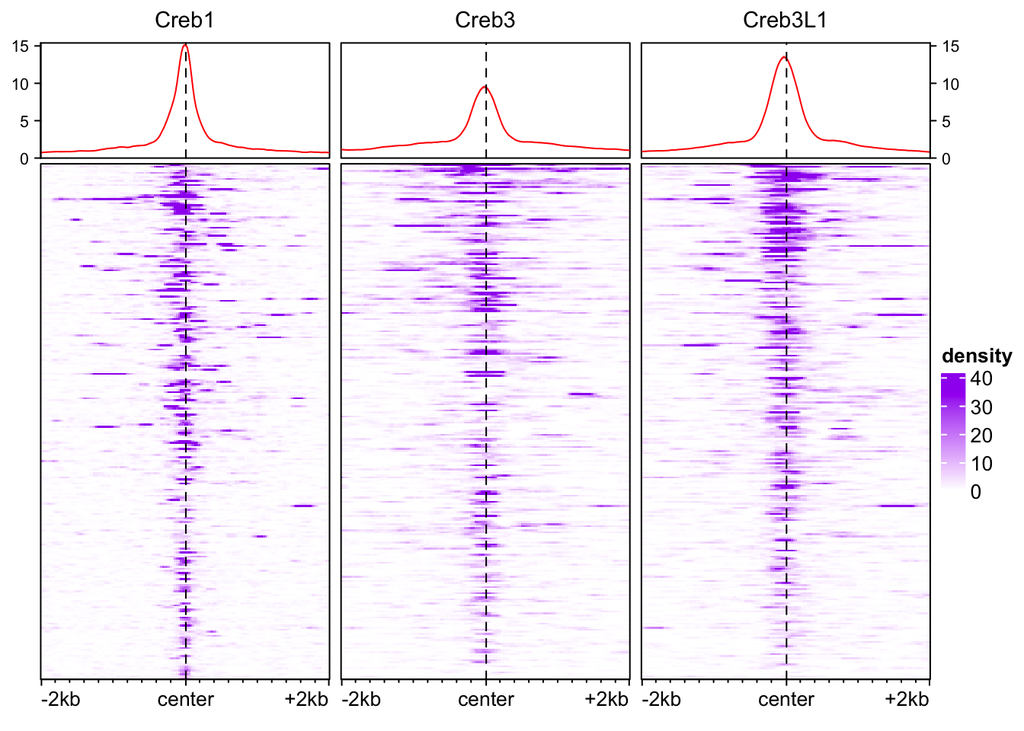

```r
#vertically, the regions are sorted by intensity, with high intensity higher up, which is quite suboptimal to see patterns

# we could do extra normalization if needed
# nf <- getNormFactors(tracks, useSeqLevels="chr1")
# ml <- rescaleSignalMatrices(ml, scaleFactors=nf)

plotEnrichedHeatmaps(ml, colors=c("white", "purple"))
```

##Clustering ###Determine how many clusters we should be using by elbow method:

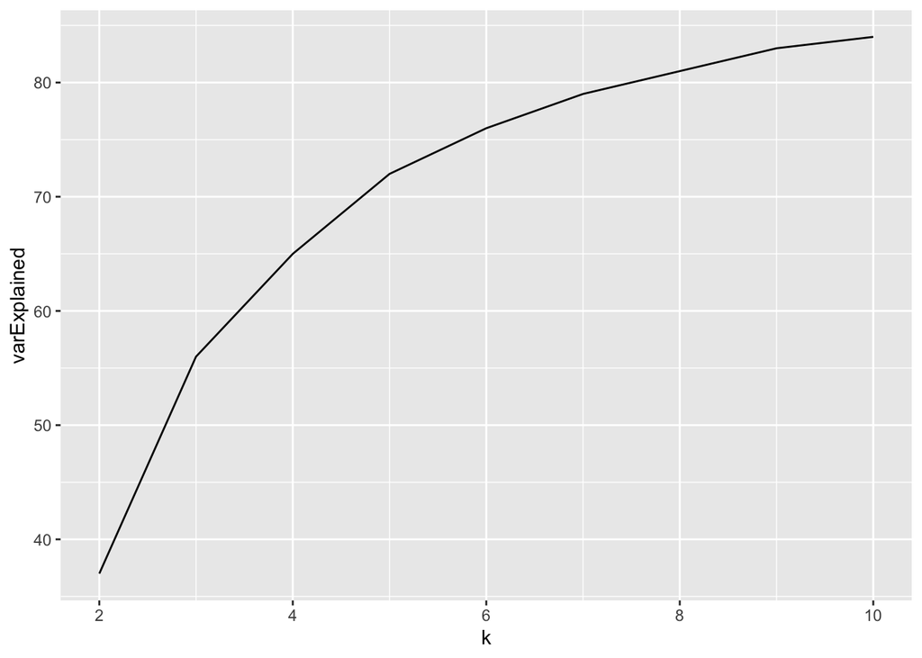

```r
#trying from two to ten clusters
#give us proportion of variance explained (to establish how many clusters we should ideally use)
cls <- clusterSignalMatrices(ml, k = 2:10)
ggplot(cls$varExplained, aes(k, varExplained)) + geom_line()
```

```r
#The elbow is at 3 clusters, but only 55% of variance explained
#Thus I will opt for 6 clusters, which explains ~76% of variance
```

```r
#k (for clustering) = number of clusters
cl <- clusterSignalMatrices(ml, k = 6)
```

```
##   ~75% of the variance explained by clusters
```

```r
#to get overview of clusters
table(cl)
```

```
## cl
##   1   2   3   4   5   6
## 608  84 144 331 705 397
```

###Plot clustered heatmap

[output not shown]

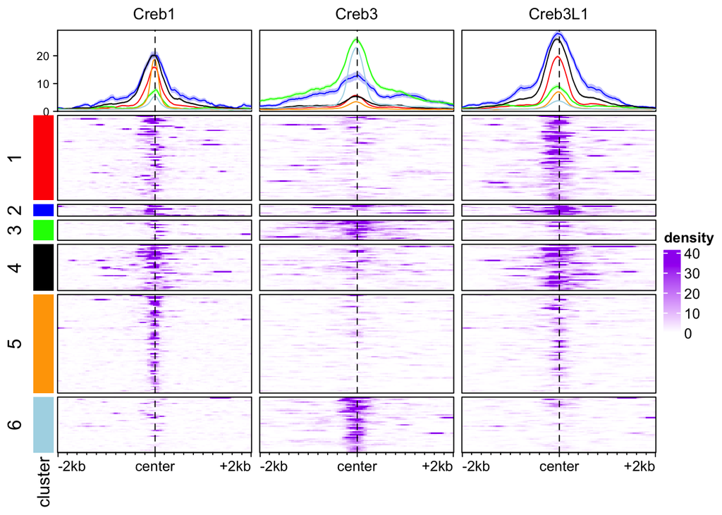

```r
#create vector that associates each name of clusters (here digits) to a colour
mycolors <- c("1"="red", "2" = "blue", "3"="green", "4"= "black", "5" = "orange", "6" = "lightblue")
#pass this vector of colours to the heat map function
plotEnrichedHeatmaps(ml, colors=c("white", "purple"), row_split = cl, mean_color = mycolors)
```